# Chapter 07: Nonlinear functional form

Runnable workbook for Regression with R and Python

This runnable workbook supplements the reference workbook. It adds setup code and lightweight fixes so the chapter can usually be rendered and run end-to-end.

- Runnable companion script: R/chapter07.R
- Reference workbook: chapter07_workbook.Rmd
- Textbook chapter: `Nonlinear functional form`
- Package installation lines are shown as comments and are not run automatically during rendering.

## Air pollution and weather in R

### Box 01

Textbook context: Section: Example: Relationship between weather and air pollution.

```r
    df <- read.csv("pollution_sf.csv")
```

### Box 02

Textbook context: Section: Example: Relationship between weather and air pollution.

```r
 df$wind_cat <- cut(df$wind_direction,
 breaks=seq(0, 360, by=10),
 include.lowest=TRUE)
```

### Box 03

Textbook context: Section: Example: Relationship between weather and air pollution.

```r
    df_agg <- aggregate(df$pm25,
                        by=list(wind_dir_interval=df$wind_cat),
                        FUN=mean)
    df_agg$wind_direction <- seq(5, 355, 10)
```

### Box 04

Textbook context: Section: Example: Relationship between weather and air pollution.

```r
    names(df_agg)[names(df_agg) == "x"] <- "pm25_mean"
```

### Box 05

Textbook context: Section: Example: Relationship between weather and air pollution.

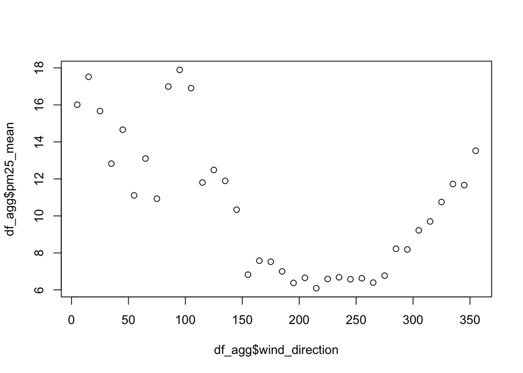

```r
    plot(df_agg$wind_direction, df_agg$pm25_mean)
```

### Box 06

Textbook context: Section: Example: Relationship between weather and air pollution.

```r
    df$north_wind <- ifelse(df$wind_direction > 315 |
                            df$wind_direction <= 45, 1, 0)
    df$east_wind <- ifelse(df$wind_direction > 45 &
                            df$wind_direction <= 135, 1, 0)
    df$south_wind <- ifelse(df$wind_direction > 135 &
                            df$wind_direction <= 225, 1, 0)
    df$west_wind <- ifelse(df$wind_direction > 225 &
                            df$wind_direction <= 315, 1, 0)
    df$land_wind <- ifelse(df$wind_direction > 330 |
                           df$wind_direction <= 150, 1, 0)
    df$strong_wind <- ifelse(df$wind_speed >= 3, 1, 0)
```

### Box 07

Textbook context: Section: Example: Relationship between weather and air pollution.

```r
    df$wind_direction2 <- df$wind_direction^2
    df$wind_direction3 <- df$wind_direction^3
    df$wind_direction4 <- df$wind_direction^4
```

### Box 08

Textbook context: Section: Example: Relationship between weather and air pollution.

```r
    ols_model_poly <- lm(pm25 ~ wind_direction +
      wind_direction2 + wind_direction3 +
      wind_direction4, data=df)
```

### Box 09

Textbook context: Section: Example: Relationship between weather and air pollution.

```r
    ols_model_poly_alt <- lm(pm25 ~
      poly(wind_direction, 4), data=df)
```

### Box 10

Textbook context: Section: Example: Relationship between weather and air pollution.

```r
    newdata <- data.frame(wind_direction=seq(0, 360, 1))
```

### Box 11

Textbook context: Section: Example: Relationship between weather and air pollution.

```r
 newdata$pred <- predict(ols_model_poly_alt, newdata)
```

### Box 12

Textbook context: Section: Example: Relationship between weather and air pollution.

```r
    newdata$pred_alt <- coef(ols_model_poly)[1] +
      coef(ols_model_poly)[2] * newdata$wind_direction +
      coef(ols_model_poly)[3] * newdata$wind_direction^2 +
      coef(ols_model_poly)[4] * newdata$wind_direction^3 +
      coef(ols_model_poly)[5] * newdata$wind_direction^4
```

### Box 13

Textbook context: Section: Example: Relationship between weather and air pollution.

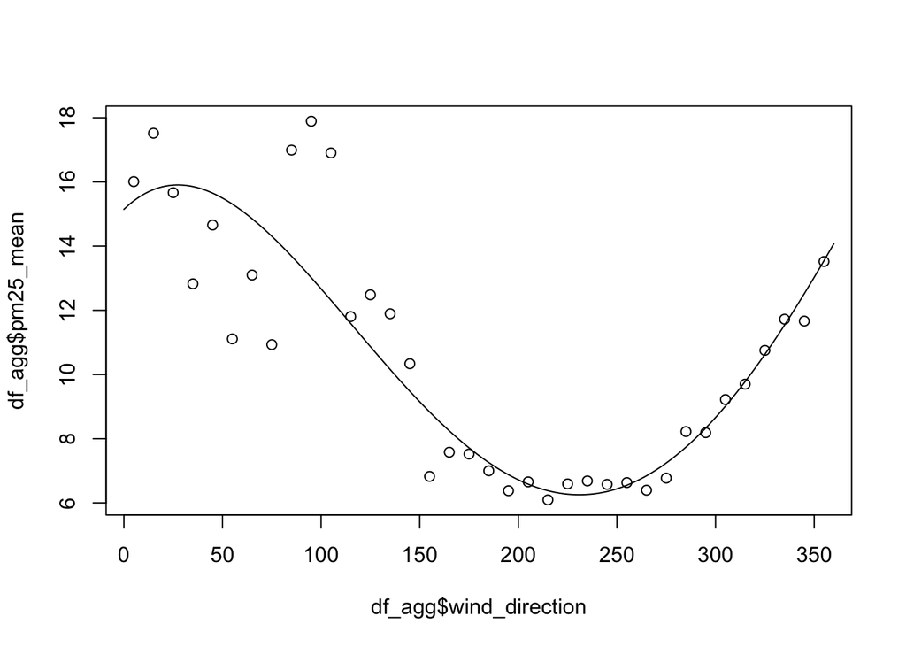

```r
 plot(df_agg$wind_direction, df_agg$pm25_mean)
 lines(newdata$wind_direction, newdata$pred)
```

### Box 14

Textbook context: Section: Example: Relationship between weather and air pollution.

```r
 df$land_wind_strong_wind <- df$land_wind * df$strong_wind
 df$land_wind_wind_speed <- df$land_wind * df$wind_speed
```

### Box 15

Textbook context: Section: Example: Relationship between weather and air pollution.

```r
    library("lmtest")
    library("sandwich")
    ols_model1 <- lm(pm25 ~ land_wind, data=df)
    ols_model2 <- lm(pm25 ~ land_wind + strong_wind +
                     land_wind_strong_wind, data=df)
    ols_model3 <- lm(pm25 ~ land_wind + wind_speed +
                     land_wind_wind_speed, data=df)
    coeftest(ols_model1, vcov=vcovHC(ols_model1, type="HC0"))
```

```
#>
#> t test of coefficients:
#>
#>             Estimate Std. Error t value  Pr(>|t|)
#> (Intercept)  7.91584    0.11406  69.402 < 2.2e-16 ***
#> land_wind    5.62899    0.45002  12.508 < 2.2e-16 ***
#> ---
#> Signif. codes:  0 '***' 0.001 '**' 0.01 '*' 0.05 '.' 0.1 ' ' 1
```

```r
    coeftest(ols_model2, vcov=vcovHC(ols_model2, type="HC0"))
```

```
#>
#> t test of coefficients:
#>
#>                       Estimate Std. Error t value  Pr(>|t|)
#> (Intercept)            8.57574    0.17684 48.4938 < 2.2e-16 ***
#> land_wind              6.53382    0.57155 11.4317 < 2.2e-16 ***
#> strong_wind           -1.60644    0.20728 -7.7502 1.136e-14 ***
#> land_wind_strong_wind -4.86723    0.72044 -6.7559 1.608e-11 ***
#> ---
#> Signif. codes:  0 '***' 0.001 '**' 0.01 '*' 0.05 '.' 0.1 ' ' 1
```

```r
    coeftest(ols_model3, vcov=vcovHC(ols_model3, type="HC0"))
```

```
#>
#> t test of coefficients:
#>
#>                       Estimate Std. Error t value  Pr(>|t|)
#> (Intercept)           9.947479   0.302000 32.9386 < 2.2e-16 ***
#> land_wind            11.170586   1.140965  9.7905 < 2.2e-16 ***
#> wind_speed           -0.658851   0.069218 -9.5185 < 2.2e-16 ***
#> land_wind_wind_speed -2.347548   0.310150 -7.5691 4.566e-14 ***
#> ---
#> Signif. codes:  0 '***' 0.001 '**' 0.01 '*' 0.05 '.' 0.1 ' ' 1
```